# Data Science Specialism

### Module 5 - Reproducible research (May 2015)

### DATA ANALYST: Fiona

### Date: 2015 May 13

## Project One - Investigating the number of steps taken as recorded by a personal activity monitoring device during October and November 2012.

### How the data was collected?

The device collected data at 5 minute intervals through out the day. The data consists of two months of data from an anonymous individual collected during the months of October and November 2012 and include the number of steps taken in 5 minute intervals for every day of the two months.

### R SCRIPT

```r
##1 - Preprocessing of the raw data into analytical data - three steps

    ##1.1 - loading libraries
    library(data.table)
    library(dplyr)
    library(reshape2)
    library(ggplot2)
    library(knitr)
    library(rmarkdown)

    ##NOTE - for knitr/rmarkdown to work in RCONSOLE you are required to download the PANDOC package available online at: http://pandoc.org/installing.html

        ##1.2 - loading the dataset
        dataset <- read.table("activity.csv", header = TRUE, sep = ",")

            ##1.3 - converting the date in the date readable format yyyy-mm-dd
            dataset$date <- strptime(dataset$date, format = "%Y-%m-%d")

                ##1.4 changing interval from int to numeric then to four characters
                dataset$interval <- as.numeric(dataset$interval)
                dataset$interval <- sprintf("%04d", dataset$interval)
```

## QUESTION 1 - What is mean total number of steps taken per day?

```
ADDITIONAL INSTRUCTIONS - "for this part of the assignment, you can IGNORE the missing values in the dataset".
```

```r
    ##1 - additional data processing - removing the NA values

        ##1.1 - removing na values
        nasubset <- na.omit(dataset)

            ##1.2 - removing interval column
            nasubset <- nasubset[c(1:2)]

                ##1.3 - calculating total number of steps taken every day by melting/dcast (reshape2 package)
                meltedsubset <- melt(nasubset, id.vars = "date")
                totalsteps <- dcast(meltedsubset, date ~ variable, sum)
```

### PART 1 (Q1) - Plot a histogram - total number of steps taken each day.

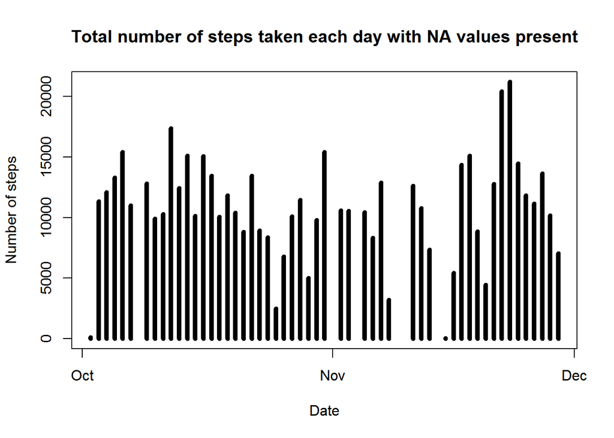

```r
    ##1 - plotting the histogram
    with (totalsteps, {
    plot(date, steps, main = "Total number of steps taken each day with NA values present", type = "h", xlab = "Date", ylab = "Number of steps", lwd = 5)
    })
```

### PART 2 (Q1) - Calculate and report the mean and median of the total number of steps taken per day.

```r
    ##1 - mean value calculation
    mean(totalsteps$steps)
```

```
## [1] 10766.19
```

```r
        ##2 - median value calculation
        median(totalsteps$steps)
```

```
## [1] 10765
```

### QUESTION 2 - What is the average daily activity pattern?

```r
    ##2 - additional processing of dataset

        ##2.1 - starting new dataset for the analysis
        patterndataset <- dataset

            ##2.2 - removing na values
            napattern <- na.omit(patterndataset)

                ##2.3 - removing the date column
                napattern <- napattern[c(3, 1)]

                    ##2.4 - calculating the mean total number of steps per interval
                    meltedpattern <- melt(napattern, id.vars = "interval")
                    totalinterval <- dcast(meltedpattern, interval ~ variable, mean)
```

### PART 1 (Q2) - Make a time series plot (i.e. type = “l”) of the 5-minute interval (x-axis) and the average number of steps taken, averaged across all days (y-axis)

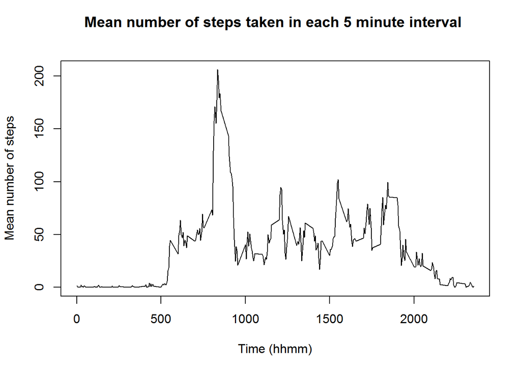

```r
    ##2.1 - plotting the graph
    with (totalinterval, {
    plot(interval, steps, main = "Mean number of steps taken in each 5 minute interval \n", type = "l", xlab = "Time (hhmm)", ylab = "Mean number of steps")
    })
```

### PART 2 (Q2) - Which 5-minute interval, on average across all the days in the dataset, contains the maximum number of steps?

```r
    ##2.2.1 - finding the maximum number of steps
    interval <- sort(totalinterval$steps, decreasing = TRUE)

        ##2.2.2 - locating the row number for "interval"
        rownumber <- match(interval, totalinterval$steps)

            ##2.2.3 - output - the 5-minute interval
            head(totalinterval[rownumber,],1)
```

```
##     interval    steps
## 104     0835 206.1698
```

```r
    ##additional data processing

    ##3.1 - starting with a fresh dataset for the analysis
    valuesna <- read.table("activity.csv", header = TRUE, sep = ",")

        ##3.2 changing interval from int to numeric then to four characters
        valuesna$interval <- as.numeric(valuesna$interval)
        valuesna$interval <- sprintf("%04d", valuesna$interval)
```

```r
    ##3.3 - calculating the number of rows with NA values
    countnasubset <- sum(complete.cases(valuesna))
    countnasubset
```

```
## [1] 15264
```

### PART 1 (Q3) - Devise a STRATEGY for filling in all of the missing values in the dataset. The strategy does not need to be sophisticated. For example, you could use the mean/median for that day, or the mean for that 5-minute interval, etc.

### MY STRATEGY: For this part of the data processing I am replacing the NA values in each interval period with the mean value for that particular interval, and those values are shown below. Then I created code to build a new column called “steps” and fill it will the exact step values or replacements for the NA values.

```r
    ##3.1.1 - starting with a fresh dataset for the calculated mean totals for each interval period. And the values are:
    intervalreplacements <- totalinterval
    intervalreplacements
```

```
##     interval       steps
## 1       0000   1.7169811
## 2       0005   0.3396226
## 3       0010   0.1320755
## 4       0015   0.1509434
## 5       0020   0.0754717
## 6       0025   2.0943396
## 7       0030   0.5283019
## 8       0035   0.8679245
## 9       0040   0.0000000
## 10      0045   1.4716981
## 11      0050   0.3018868
## 12      0055   0.1320755
## 13      0100   0.3207547
## 14      0105   0.6792453
```

[output cut: 274 more lines]

### PART 2 (Q3) - Create a new dataset that is equal to the original dataset but with the missing data filled in.

```r
    ##calculating a new column with number of steps - actual values or replacement values for NAs

    ##3.2.1 - merging the two dataset by interval values
    mergena <- merge(valuesna, intervalreplacements, by = "interval")

            ##3.2.2 - creating the new column
            mergena$steps <- 0

                ##3.2.3 - the calculation
                rownumber = seq(1, 17568)
                for (i in rownumber) {
                    if (is.na(mergena$steps.x[i])) {
                        mergena$steps[i] <- mergena$steps.y[i]
                            } else {
                                mergena$steps[i] <- mergena$steps.x[i]
                    }
                }

                    ##3.2.4 - removing the unwanted columns so this dataset matches the original dataset
                    finalsubset <- mergena[c(5,3,1)]

    ##3.2.5 - displaying the first and last rows from original (dataset) and non NA (finalsubset) showing that the NAs have been removed
    head(dataset, 1)
```

```
##   steps       date interval
## 1    NA 2012-10-01     0000
```

```r
    head(finalsubset, 1)
```

```
##      steps       date interval
## 1 1.716981 2012-10-01     0000
```

```r
    tail(dataset, 1)
```

```
##       steps       date interval
## 17568    NA 2012-11-30     2355
```

```r
    tail(finalsubset, 1)
```

```
##          steps       date interval
## 17568 1.075472 2012-11-30     2355
```

### PART 3 (Q3) - Make a histogram of the total number of steps taken each day. Calculate and report the mean and median total number of steps taken per day. Do these values differ from the estimates from the first part of the assignment? What is the impact of imputing missing data on the estimates of the total daily number of steps?

```r
    ##additional processing of dataset

    ##3.3.1 - removing the interval column
    finalsubset <- finalsubset[c(1:2)]

        ##3.3.2 - converting the date in the date readable format yyyy-mm-dd
        finalsubset$date <- strptime(finalsubset$date, format = "%Y-%m-%d")

            ##3.3.3 - calculating the mean total number of steps per interval
            meltedpattern <- melt(finalsubset, id.vars = "date")
            finalna <- dcast(meltedpattern, date ~ variable, sum)
```

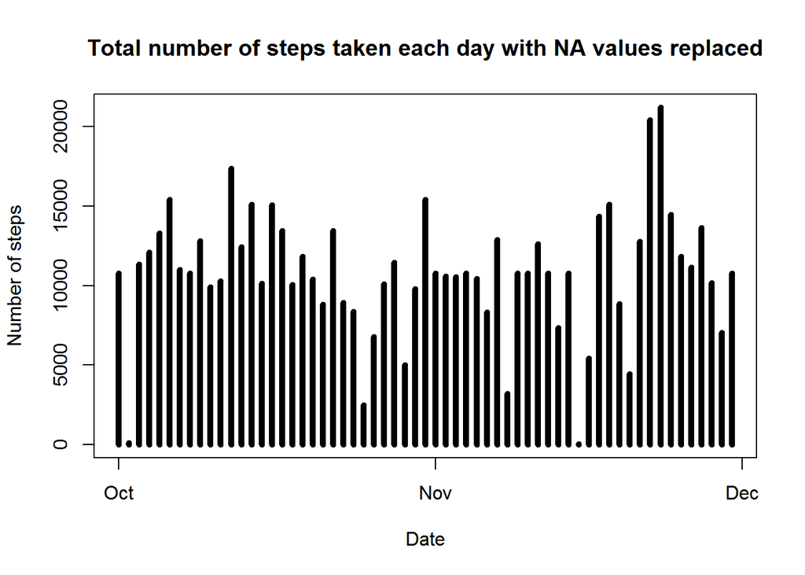

```r
    ##3.3.4 - plotting the graph
    with (finalna, {
    plot(date, steps, main = "Total number of steps taken each day with NA values replaced", type = "h", xlab = "Date", ylab = "Number of steps", lwd = 5)
    })
```

```r
    ##calculating mean and median values

    ##3.3.5 - mean value calculation
    mean(finalna$steps)
```

```
## [1] 10766.19
```

```r
        ##3.3.6 - median value calculation
        median(finalna$steps)
```

```
## [1] 10766.19
```

```
##how do values differ with NA and without NA values?

The median value for the replaced missing values dataset  has increased and shifted to the mean value as shown in the table below.
```

```r
    ##3.3.7 - creating a mini data table of the mean and median results for comparison
    comparison <- matrix(1:2, 2,3)
    meanvalue1 <- mean(totalsteps$steps)
    medianvalue1 <- median(totalsteps$steps)
    meanvalue2 <- mean(finalna$steps)
    medianvalue2 <- median(finalna$steps)
    values1 <- cbind("with NA", meanvalue1, medianvalue1)
    values2 <- cbind("replaced NA", meanvalue2, medianvalue2)
    comparison <- rbind(values1, values2)
    colnames(comparison) <- c("analysis?", "mean value", "median value")
    comparison
```

```
##      analysis?     mean value         median value
## [1,] "with NA"     "10766.1886792453" "10765"
## [2,] "replaced NA" "10766.1886792453" "10766.1886792453"
```

[output not shown]

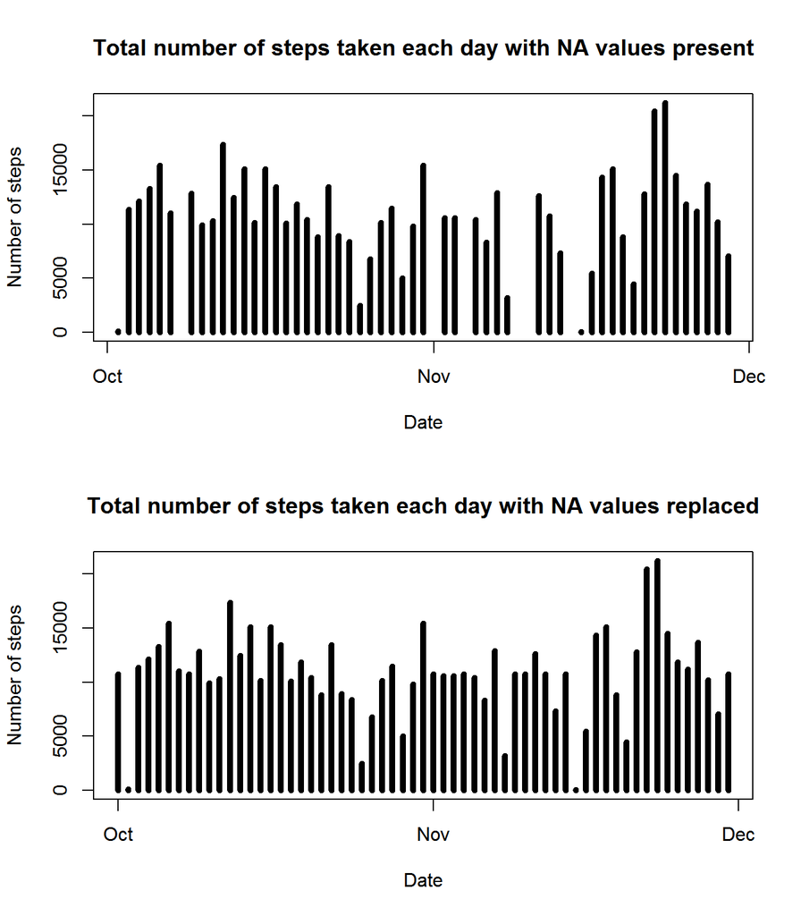

```r
    ##What is impact of replacing NA with mean interval value?

    ##3.3.8 - plotting the two graphs
    par(mfrow = c(2,1))
    with (totalsteps, {
    plot(date, steps, main = "Total number of steps taken each day with NA values present", type = "h", xlab = "Date", ylab = "Number of steps", lwd = 5)
    })

        with (finalna, {
        plot(date, steps, main = "Total number of steps taken each day with NA values replaced", type = "h", xlab = "Date", ylab = "Number of steps", lwd = 5)
        })
```

## QUESTION 4 - Are there differences in activity patterns between weekdays and weekends?

[output not shown]

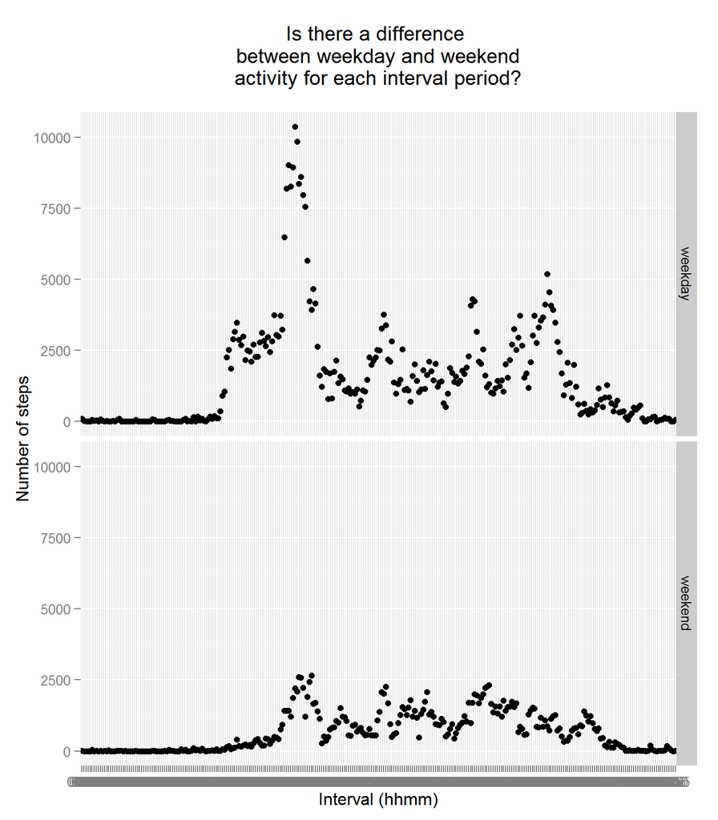

```r
    ##4.1 - starting with a new dataset with the replaced NA values
    weekends <- mergena[c(3,1,5)]

    ##additional processing of data

        ##4.2 - converting the date in the date readable format yyyy-mm-dd
        weekends$date <- strptime(weekends$date, format = "%Y-%m-%d")

            ##4.3 - calculating the weekdays from the date
            day <- weekdays(weekends$date, abbreviate = TRUE)

                ##4.4 - merging the datasets
                daydate <- cbind(weekends, day)

                    ##4.5 - removing the date column
                    daydate <- daydate[c(2:4)]

                        ##4.6 - calculating the sum values for each day and time interval
                        meltweekends <- melt(daydate, id.vars = c("interval", "day"))
                        weekdayorend <- dcast(meltweekends, interval + day ~ variable, sum)

    ##determining whether a day is a weekday or weekend

    ##4.7 - creating a new column
    weekdayorend$daytype <- 0

        ##4.8 - the calculation
        numberrow = seq(1, 2016)
        for (i in numberrow) {
            if (weekdayorend$day[i] == "Sat" | weekdayorend$day[i] == "Sun") {
                weekdayorend$daytype[i] <- "weekend"
                    } else {
                        weekdayorend$daytype[i] <- "weekday"
            }
        }

            ##4.9 - removing day column
            weekdayorend <- weekdayorend[c(1, 3, 4)]

                ##4.10 - calculating the sum values for weekend or weekday and time interval
                melting <- melt(weekdayorend, id.vars = c("interval", "daytype"))
                weekdayorend <- dcast(melting, interval + daytype ~ variable, sum)

    ##4.11 - plotting the final graph
    qplot(interval, steps, data = weekdayorend, facets = daytype~., xlab = "Interval (hhmm)", ylab = "Number of steps", main = "Is there a difference \n between weekday and weekend \n activity for each interval period? \n")
```

render(“PA1_template.Rmd”, html_document())